# Analyzing the Stroop Effect

### *Student: Ryan S.*

In this project, you will investigate a classic phenomenon from experimental psychology called the Stroop Effect. You will learn a little bit about the experiment, create a hypothesis regarding the outcome of the task, then go through the task yourself. You will then look at some data collected from participants who performed the Stroop test and will compute some statistics describing the results. Finally, you will interpret your results in terms of your hypotheses.

**NOTE:** All content in blue was added by me.

```python
# Import Libraries
import numpy as np
import pandas as pd
% matplotlib inline
import matplotlib.pyplot as plt
import seaborn as sns
import statsmodels.api as sm;
import scipy.stats as stats
from scipy.stats import t
from scipy.stats import kurtosis, skew
import math
import warnings
warnings.filterwarnings('ignore')

# Centers all charts in the document
from IPython.core.display import HTML
HTML("""
<style>
.output_png {
    display: table-cell;
    text-align: center;
    vertical-align: middle;
}
</style>
""")
```

```python
#Import data
df = pd.read_csv('stroopdata.csv')
```

## Exploring the Data

I always explore the data briefly before starting to work with it.

```python
df.shape
```

```
(24, 2)
```

```python
df
```

|  | Congruent | Incongruent |
| --- | --- | --- |
| 0 | 12.079 | 19.278 |
| 1 | 16.791 | 18.741 |
| 2 | 9.564 | 21.214 |
| 3 | 8.630 | 15.687 |
| 4 | 14.669 | 22.803 |
| 5 | 12.238 | 20.878 |
| 6 | 14.692 | 24.572 |
| 7 | 8.987 | 17.394 |
| 8 | 9.401 | 20.762 |
| 9 | 14.480 | 26.282 |
| 10 | 22.328 | 24.524 |
| 11 | 15.298 | 18.644 |
| 12 | 15.073 | 17.510 |
| 13 | 16.929 | 20.330 |
| 14 | 18.200 | 35.255 |
| 15 | 12.130 | 22.158 |
| 16 | 18.495 | 25.139 |
| 17 | 10.639 | 20.429 |
| 18 | 11.344 | 17.425 |
| 19 | 12.369 | 34.288 |
| 20 | 12.944 | 23.894 |
| 21 | 14.233 | 17.960 |
| 22 | 19.710 | 22.058 |
| 23 | 16.004 | 21.157 |

```python
df.dtypes
```

```
Congruent      float64
Incongruent    float64
dtype: object
```

## **(1) What is the independent variable? What is the dependent variable?**

The **independent** variable is the *words condition*, either **congruent** (the word is a color, and the ink/font color of the word matches) or **incongruent** (the ink/font color of the word does not match).

Examples:

- Congruent: RED
- Incongruent: ORANGE

The **dependent** variable is the amount of time it takes someone to state the color of the ink/font for each *word condition*.

## **(2) What is an appropriate set of hypotheses for this task? Specify your null and alternative hypotheses, and clearly define any notation used. Justify your choices.**

**Data:**

The data contains the results from 24 people who were timed at how long it took them to state the ink/font color from both **congruent** and **incongruent** words.

When looking at the data, we can make several assumptions:

1. The times recorded are continuous data
2. Each participant in the test is independent of each other
3. Each participant recorded a time for both word conditions, therefore the data is dependent and considered paired
4. The times recorded (dependent variable) are normallly distributed

**Hypotheses:**

I'm basing my hypothesis on the idea that we do not know if a person can identify the color of an **incongruent** word faster or slower than a **congruent** word, or if the word condition has no effect on the time. Therefore, to cover all possibilities:

$$\Large H_0: \mu_{Incongruent} - \mu_{Congruent} = 0$$

$$\Large H_1: \mu_{Incongruent} - \mu_{Congruent} \neq 0$$

The **Null** hypothesis is that the amount of time it takes someone to state the ink/font color of an incongruent word is the same as stating a congruent word. This is denoted by subtracting the hypothetical population mean of the Congruent column from the hypothetical population mean of the Incongruent column and the difference being equal.

The **Alternative** hypothesis is that the amount of time it takes someone to state the ink/font color of an incongruent word is different (longer or shorter) than stating a congruent word. This is denoted by subtracting the hypothetical population mean of the Congruent column from the hypothetical population mean of the Incongruent column and the difference being greater or less than zero.

**Test:**

Based on this information, I will perform a **dependent t-test for paired samples** using the mean difference. A t-test is appropriate because the sample size is under 30, and it will help reduce some of the bias with the small sample size. Since the alternative hypothesis contain a $\neq$, this will be a two-tailed test.

## (3) Report some descriptive statistics regarding this dataset. Include at least one measure of central tendency and at least one measure of variability.

I am adding a column that will calculate the difference between the **Congruent** and **Incongruent** columns.

```python
df['Difference'] = df.Incongruent - df.Congruent
df.head()
```

|  | Congruent | Incongruent | Difference |
| --- | --- | --- | --- |
| 0 | 12.079 | 19.278 | 7.199 |
| 1 | 16.791 | 18.741 | 1.950 |
| 2 | 9.564 | 21.214 | 11.650 |
| 3 | 8.630 | 15.687 | 7.057 |
| 4 | 14.669 | 22.803 | 8.134 |

### Central Tendency

```python
# Mean of each column
df.mean()
```

```
Congruent      14.051125
Incongruent    22.015917
Difference      7.964792
dtype: float64
```

```python
# Median for each column
df.median()
```

```
Congruent      14.3565
Incongruent    21.0175
Difference      7.6665
dtype: float64
```

```python
# Basic descriptive statistics
df.describe()
```

|  | Congruent | Incongruent | Difference |
| --- | --- | --- | --- |
| count | 24.000000 | 24.000000 | 24.000000 |
| mean | 14.051125 | 22.015917 | 7.964792 |
| std | 3.559358 | 4.797057 | 4.864827 |
| min | 8.630000 | 15.687000 | 1.950000 |
| 25% | 11.895250 | 18.716750 | 3.645500 |
| 50% | 14.356500 | 21.017500 | 7.666500 |
| 75% | 16.200750 | 24.051500 | 10.258500 |
| max | 22.328000 | 35.255000 | 21.919000 |

### Variability - Range & Interquartiles

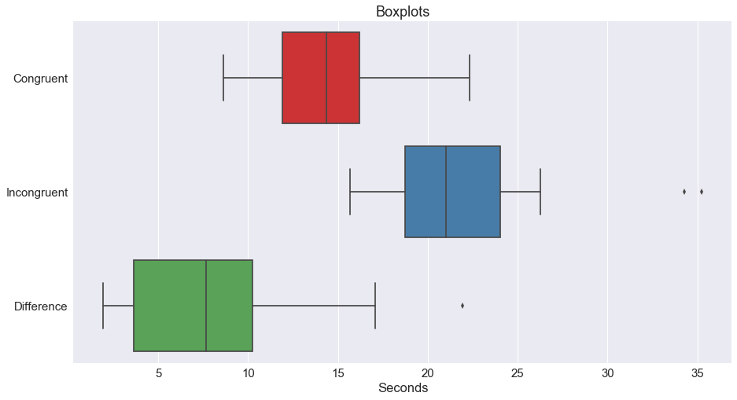

```python
# Boxplots
plt.figure(figsize=(15,8))
sns.set(style="darkgrid", font_scale=1.5, palette='Set1')
sns.boxplot(data=df, orient="h");
plt.title('Boxplots');
plt.xlabel('Seconds');
```

The boxplots above shows that the **congruent** column has a tighter IQR than the **incongruent** column. This is confirmed by the IQR calculations below. The **incongruent** column has a few outliers, and this gets passed on to the difference column. Additionally, the IQR for the **difference** column being larger than the other two columns shows that there is some distance between the **congruent** and **incongruent** columns.

#### Congruent

```python
# Full range - Congruent (The highest and lowest values in the column subtracted)
df.Congruent.max() - df.Congruent.min()
```

```
13.698000000000002
```

```python
# Calculating IQR
qc75, qc25 = np.percentile(df.Congruent, [75,25])
iqrc = qc75 - qc25
iqrc
```

```
4.3054999999999986
```

```python
# Calculating the lower inner outlier fence
minc = qc25 - (iqrc * 1.5)
minc
```

```
5.437000000000003
```

```python
# Calculating the upper inner outlier fence
maxc = qc75 + (iqrc * 1.5)
maxc
```

```
22.659
```

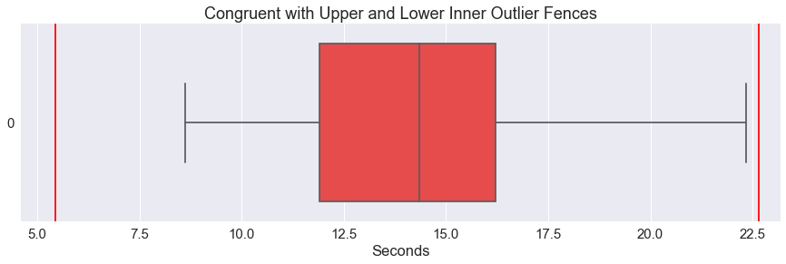

```python
plt.figure(figsize=(15,4))
sns.set(style="darkgrid", font_scale=1.5)
sns.boxplot(data=df.Congruent, orient="h", color='#FF3333');
plt.axvline(x=minc, color='r');
plt.axvline(x=maxc, color='r');
plt.title('Congruent with Upper and Lower Inner Outlier Fences');
plt.xlabel('Seconds');
```

#### Incongruent

```python
# Full range - Congruent (The highest and lowest values in the column subtracted)
df.Incongruent.max() - df.Incongruent.min()
```

```
19.568
```

```python
# Calculating Interquartile Range - Incongruent
qi75, qi25 = np.percentile(df.Incongruent, [75,25])
iqri = qi75 - qi25
iqri
```

```
5.33475
```

```python
# Calculating the lower inner outlier fence
mini = qi25 - (iqri * 1.5)
```

```python
# Calculating the upper inner outlier fence
maxi = qi75 + (iqri * 1.5)
```

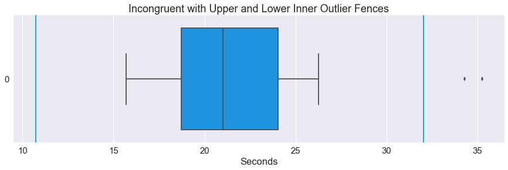

```python
plt.figure(figsize=(15,4))
sns.set(style="darkgrid", font_scale=1.5)
sns.boxplot(data=df.Incongruent, orient="h", color='#0099FF');
plt.axvline(x=mini, color='#0099FF');
plt.axvline(x=maxi, color='#0099FF');
plt.title('Incongruent with Upper and Lower Inner Outlier Fences');
plt.xlabel('Seconds');
```

```python
# This shows how many outliers there are; we can see them in the chart in this instance,
#    but in other cases you could have more than you could count, plus the possibility of overlapping
df.Incongruent[df.Incongruent > maxi].count()
```

```
2
```

```python
# This calculates what percent of the values in the column are outliers
df.Incongruent[df.Incongruent > maxi].count() / len(df)
```

```
0.08333333333333333
```

8.3% of the Incongruent column is outliers.

#### Difference

```python
# Interquartile range - Difference
np.subtract(*np.percentile(df.Difference, [75, 25]))
```

```
6.613000000000001
```

```python
# Full range - Difference
df.Difference.max() - df.Difference.min()
```

```
19.969000000000005
```

### Variability - Standard Deviation

```python
df.std()
```

```
Congruent      3.559358
Incongruent    4.797057
Difference     4.864827
dtype: float64
```

## **(4) Provide one or two visualizations that show the distribution of the sample data. Write a few sentences noting what you observe about the plot or plots.**

### Distribution Plot

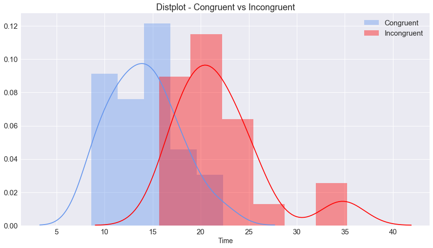

```python
# Distplot
plt.figure(figsize=(15,8))
sns.set(style="darkgrid", font_scale=1.5)
sns.distplot(df.Congruent, color="cornflowerblue", label="Congruent");
sns.distplot(df.Incongruent, color="red", label="Incongruent");
plt.title('Distplot - Congruent vs Incongruent')
plt.xlabel('Time', fontsize=14);
plt.legend();
```

```python
print("Congruent skew:", skew(df.Congruent), "     Incongruent skew:", skew(df.Incongruent))
```

```
Congruent skew: 0.3903776149050634      Incongruent skew: 1.4491357281474857
```

```python
# Note that this is the EXCESS kurtosis, i.e. amounts above or below 3
print("Congruent kurtosis:", kurtosis(df.Congruent), "     Incongruent kurtosis:", kurtosis(df.Incongruent))
```

```
Congruent kurtosis: -0.4048936841311468      Incongruent kurtosis: 1.920472855091183
```

#### Observations - Distplot

The distribution chart above shows a combination of a histogram with a density plot, comparing the distributions of the **Congruent** and **Incongruent** columns. Below the chart I show the measure of skew and kurtosis for each.

The **congruent** plot shows a unimodal distribution with a slight right skew of 0.39. The negative kurtosis indicates there is less data in the tails.

The **incongruent** plot shows a non-symmetric bimodal distribution with a more pronounced right skew of 1.45. The bimodal nature of that plot is caused by the outliers in this set of data, as shown in the boxplots from the previous question. It is also the reason the excess kurtosis is at 1.92; the outliers are increasing the amount of data in the tails.

### Scatterplot

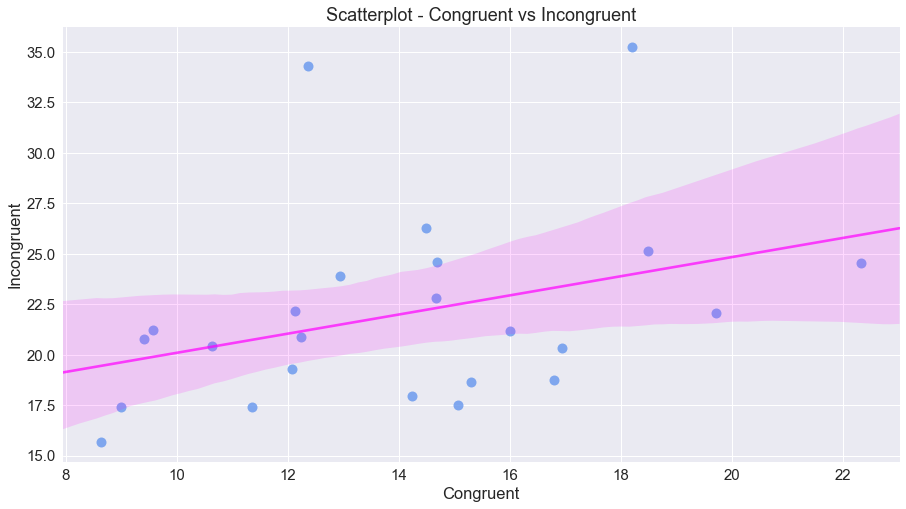

```python
# Scatterplot
plt.figure(figsize=(15,8))
sns.set(style="darkgrid", font_scale=1.5)
p1=sns.regplot(x=df["Congruent"], y=df["Incongruent"], color="cornflowerblue",
               scatter_kws={'s':100},
               line_kws={"color":"fuchsia","alpha":0.7});
plt.title("Scatterplot - Congruent vs Incongruent");
```

```python
# Calculates the correlation between the variables
df.corr()
```

|  | Congruent | Incongruent | Difference |
| --- | --- | --- | --- |
| Congruent | 1.000000 | 0.35182 | -0.384733 |
| Incongruent | 0.351820 | 1.00000 | 0.728660 |
| Difference | -0.384733 | 0.72866 | 1.000000 |

#### Observations - Scatterplot

In the scatterplot above, I once again compared the **congruent** column to the **incongruent** column. Since each participant in the test has a value in both columns, these fields are dependent and we can look for relationships. Here we see that as **congruent** times go up, **incongruent** times go up as well, and the regression line shows this upward, albeit gradual trend. This gradual trend is reflected in the correlation coefficient of only 0.352, which is a low to moderate correlation.

## **(5) Now, perform the statistical test and report your results. What is your confidence level or Type I error associated with your test? What is your conclusion regarding the hypotheses you set up? Did the results match up with your expectations?**

**Hint:** Think about what is being measured on each individual, and what statistic best captures how an individual reacts in each environment.

### Test Setup

#### Confidence Interval

The confidence interval I am using is a standard 95%. Because this is a two-tailed test, the 5% will be split in half to cover both sides of the distribution. The upper bound will be **0.975**, which will be used when calculating the *t-critical value*.

$\normalsize \alpha = 0.05$

#### Degrees of Freedom

This is used to calculate the t-critical value.

The sample size: $\normalsize n = 24$

Degrees of Freedom: $\normalsize n - 1$

Degrees of Freedom: $\normalsize 24 - 1 = 23$

#### T-Critical Value

Calculating the t-critical value below. This could also be looked up in a t-table.

```python
# Calculating the t-critical value for a two tailed test
print("The t-critical value is", t.ppf(.975, 23))
```

```
The t-critical value is 2.0686576104190406
```

#### Difference in Means and Standard Deviation

Calculating the difference in means and the standard deviation of the difference in means. This will be used when calculating the *t-statistic*.

Recall I added the **Difference** column at the beginning of section 3, so I can simply use that for these calculations.

```python
# This is the mean difference (X bar) in our t-test below
diff = df.Difference.mean()
diff
```

```
7.964791666666667
```

```python
# This is the standard deviation of the difference in means
std_diff = df.Difference.std()
std_diff
```

```
4.864826910359056
```

### Statistical Test

The appropriate test for this scenario is the **Dependent t-test for paired samples**.

$\Huge t = \frac{\bar x_{D}\ - \ \mu_{0}}{\frac{s_{D}}{\sqrt{n}}}$  
Where:

- x bar ($\bar x_{D}$) is the mean difference of 7.964791666666667
- mu naught ($\mu_{0}$) is null hypothesis of zero
- Standard deviation of the difference in means ($s_{D}$) is 4.864826910359056
- Square root of n ($\sqrt{n}$) is 24, the number of values in sample

```python
# Calculating the t-statistic manually
diff/(std_diff/math.sqrt(24))
```

```
8.020706944109957
```

Alternatively, we can use *scipy.stats* to calculate the t-statistic, which also provides a p-value. In this scenario, the appropriate test to use is `ttest_rel`.

```python
# Calculate the t-statistic and the p-value using scipy.stats
stats.ttest_rel(df.Incongruent, df.Congruent)
```

```
Ttest_relResult(statistic=8.020706944109957, pvalue=4.103000585711178e-08)
```

### Test Results

The t-statistic of 8.0207 far exceeds the critical value of 2.0687. Additionally, the p-value of 4.1030e-08 is extremely small and is statistically significant. Therefore, **we reject the Null hypothesis**.

The low p-value tells us that the results did not occur by chance, meaning that the times for incongruent words will almost always be higher than those for congruent words.

Conclusion: The people in the study can read words faster than they can extrapolate the color of the letters in the word. This result was expected.

## References

Density plots:  
https://towardsdatascience.com/histograms-and-density-plots-in-python-f6bda88f5ac0

Plot help:  
https://python-graph-gallery.com/25-histogram-with-several-variables-seaborn/

https://python-graph-gallery.com/30-basic-boxplot-with-seaborn/

T-test help:  
https://www.statisticssolutions.com/manova-analysis-paired-sample-t-test/

T-critical value help:  
https://machinelearningmastery.com/critical-values-for-statistical-hypothesis-testing/

https://stackoverflow.com/questions/19339305/python-function-to-get-the-t-statistic

https://docs.scipy.org/doc/scipy-0.14.0/reference/generated/scipy.stats.t.html

T-tables:  
https://www.statisticshowto.datasciencecentral.com/tables/t-distribution-table/

Dependent t-test for paired samples:  
https://en.wikipedia.org/wiki/Student%27s_t-test#Dependent_t-test_for_paired_samples

scipy.stats ttest:  
https://docs.scipy.org/doc/scipy/reference/generated/scipy.stats.ttest_rel.html#scipy.stats.ttest_rel